# Projet tourbière

Kokou TETE et Eunice SITTI-MAWUBEDJRO

2025-06-24

### Partie ACP incomplète mais partie modélisation complète

## 1)

```r
#install.packages('VIM')
library(VIM)
#install.packages(ggplot2)
library(ggplot2)
#install.packages('imputeTS')
library(imputeTS)
#install.packages('corrplot')
library(corrplot)
#install.packages('missMDA')
library(missMDA)
#install.packages('dygraphs')
library(dygraphs)
#install.packages('xts')
library(xts)
library(TSA)
library(forecast)
```

# Chargement du jeux de donnees

```r
projet_st<-read.table('dataprojet1.txt', header=T)
#str(projet_st)
```

# Visualisation graphique du flux de CO2 et CH4 avec dygraph

```r
dates<-as.Date(projet_st[,1])
CO2<-projet_st[,3]
CH4<-projet_st[,4]
pro <- xts(cbind(CO2,CH4), order.by = dates)
```

# Affichage du flux de CO2

```r
dygraph(pro[,1]) %>%
  dySeries("CO2", label = "CO2", color = "blue")%>%
  dyAxis("y", label = "Valeurs") %>%
  dyOptions(strokeWidth = 1.5) %>%  # Epaisseur des traits
  dyLegend(show = "always")%>%
  dyRangeSelector()  # Permet de selectionner l'intervalle
```

[interactive chart not shown]

# Affichage du flux de CH4

```r
dygraph(pro[,2]) %>%
  dySeries("CH4", label = "CH4", color = "black")%>%
  dyAxis("y", label = "Valeurs") %>%
  dyOptions(strokeWidth = 1.5) %>%  # Epaisseur des traits
  dyLegend(show = "always")%>%
  dyRangeSelector()  # Permet de selectionner l'intervalle
```

[interactive chart not shown]

### Etude sur les valeurs manquantes

```r
sum(is.na(projet_st)) # total nber of NA  14885   Au total  val. manquantes
```

```
## [1] 14885
```

```r
sort(colSums(is.na(projet_st)))
```

```
##                  Date  lgt.pz_cbdv_aval_WTD   lgt.pz_cbdv_aval_TW
##                     0                     0                     9
##            SoilHeatd2       lgt.bm1_G_1_1_2       lgt.bm1_P_1_1_1
##                    13                    13                    13
##      lgt.bm1_PA_1_1_1 lgt.bm1_PPFD_IN_1_1_1     lgt.bm1_SWC_1_1_1
##                    13                    13                    13
##     lgt.bm1_SWC_1_1_2     lgt.bm1_SWC_1_2_1     lgt.bm1_SWC_1_3_1
##                    13                    13                    13
##      lgt.bm1_TS_1_1_1      lgt.bm1_TS_1_1_2      lgt.bm1_TS_1_2_1
##                    13                    13                    13
##      lgt.bm1_TS_1_2_2      lgt.bm1_TS_1_3_1      lgt.bm1_TS_1_3_2
##                    13                    13                    13
##      lgt.bm1_TS_1_4_1      lgt.bm1_TS_1_5_1      lgt.bm1_WD_1_1_1
##                    13                    13                    13
##      lgt.bm1_WS_1_1_1          lgt.pz_do_TW         lgt.pz_do_WTD
##                    13                    23                    23
##           lgt.bm1_WTD                    TA          lgt.pz_dc_TW
##                    25                    30                    75
##         lgt.pz_dc_WTD      lgt.bm1_RH_1_1_1 lgt.pz_cbdv_amont_WTD
##                    75                   105                   147
##  lgt.pz_cbdv_amont_TW       lgt.bm2_G_2_1_1       lgt.bm2_G_2_1_2
##                   168                   359                   359
##   lgt.bm2_LW_IN_1_1_1  lgt.bm2_LW_OUT_1_1_1   lgt.bm2_SW_IN_1_1_1
##                   359                   359                   359
##  lgt.bm2_SW_OUT_1_1_1     lgt.bm2_SWC_2_1_1     lgt.bm2_SWC_2_1_2
##                   359                   359                   359
##     lgt.bm2_SWC_2_2_1     lgt.bm2_SWC_2_3_1      lgt.bm2_TS_2_1_1
##                   359                   359                   359
##      lgt.bm2_TS_2_1_2      lgt.bm2_TS_2_2_1      lgt.bm2_TS_2_2_2
##                   359                   359                   359
##      lgt.bm2_TS_2_3_1      lgt.bm2_TS_2_4_1      lgt.bm2_TS_2_5_1
##                   359                   359                   359
##      lgt.bm2_TS_2_6_1           lgt.bm2_WTD                   ETR
##                   359                   359                   517
##                  Heat                  FCO2                 LHeat
##                   618                   621                   636
##     lgt.sm_exutoire_Q          lgt.pz_wc_TW         lgt.pz_wc_WTD
##                   688                   710                   710
##    lgt.sm_exutoire_TW                  FCH4         lgt.pz_wo_WTD
##                   787                   909                   941
```

### Proportion de na par variable

```r
na_prop <- sort(colMeans(is.na(projet_st)))
na_prop
```

```
##                  Date  lgt.pz_cbdv_aval_WTD   lgt.pz_cbdv_aval_TW
##           0.000000000           0.000000000           0.004980631
##            SoilHeatd2       lgt.bm1_G_1_1_2       lgt.bm1_P_1_1_1
##           0.007194245           0.007194245           0.007194245
##      lgt.bm1_PA_1_1_1 lgt.bm1_PPFD_IN_1_1_1     lgt.bm1_SWC_1_1_1
##           0.007194245           0.007194245           0.007194245
##     lgt.bm1_SWC_1_1_2     lgt.bm1_SWC_1_2_1     lgt.bm1_SWC_1_3_1
##           0.007194245           0.007194245           0.007194245
##      lgt.bm1_TS_1_1_1      lgt.bm1_TS_1_1_2      lgt.bm1_TS_1_2_1
##           0.007194245           0.007194245           0.007194245
##      lgt.bm1_TS_1_2_2      lgt.bm1_TS_1_3_1      lgt.bm1_TS_1_3_2
##           0.007194245           0.007194245           0.007194245
##      lgt.bm1_TS_1_4_1      lgt.bm1_TS_1_5_1      lgt.bm1_WD_1_1_1
##           0.007194245           0.007194245           0.007194245
##      lgt.bm1_WS_1_1_1          lgt.pz_do_TW         lgt.pz_do_WTD
##           0.007194245           0.012728279           0.012728279
##           lgt.bm1_WTD                    TA          lgt.pz_dc_TW
##           0.013835086           0.016602103           0.041505257
##         lgt.pz_dc_WTD      lgt.bm1_RH_1_1_1 lgt.pz_cbdv_amont_WTD
##           0.041505257           0.058107360           0.081350304
##  lgt.pz_cbdv_amont_TW       lgt.bm2_G_2_1_1       lgt.bm2_G_2_1_2
##           0.092971776           0.198671832           0.198671832
##   lgt.bm2_LW_IN_1_1_1  lgt.bm2_LW_OUT_1_1_1   lgt.bm2_SW_IN_1_1_1
##           0.198671832           0.198671832           0.198671832
##  lgt.bm2_SW_OUT_1_1_1     lgt.bm2_SWC_2_1_1     lgt.bm2_SWC_2_1_2
##           0.198671832           0.198671832           0.198671832
##     lgt.bm2_SWC_2_2_1     lgt.bm2_SWC_2_3_1      lgt.bm2_TS_2_1_1
##           0.198671832           0.198671832           0.198671832
##      lgt.bm2_TS_2_1_2      lgt.bm2_TS_2_2_1      lgt.bm2_TS_2_2_2
##           0.198671832           0.198671832           0.198671832
##      lgt.bm2_TS_2_3_1      lgt.bm2_TS_2_4_1      lgt.bm2_TS_2_5_1
##           0.198671832           0.198671832           0.198671832
##      lgt.bm2_TS_2_6_1           lgt.bm2_WTD                   ETR
##           0.198671832           0.198671832           0.286109574
##                  Heat                  FCO2                 LHeat
##           0.342003320           0.343663531           0.351964582
##     lgt.sm_exutoire_Q          lgt.pz_wc_TW         lgt.pz_wc_WTD
##           0.380741561           0.392916436           0.392916436
##    lgt.sm_exutoire_TW                  FCH4         lgt.pz_wo_WTD
##           0.435528500           0.503043719           0.520752629
```

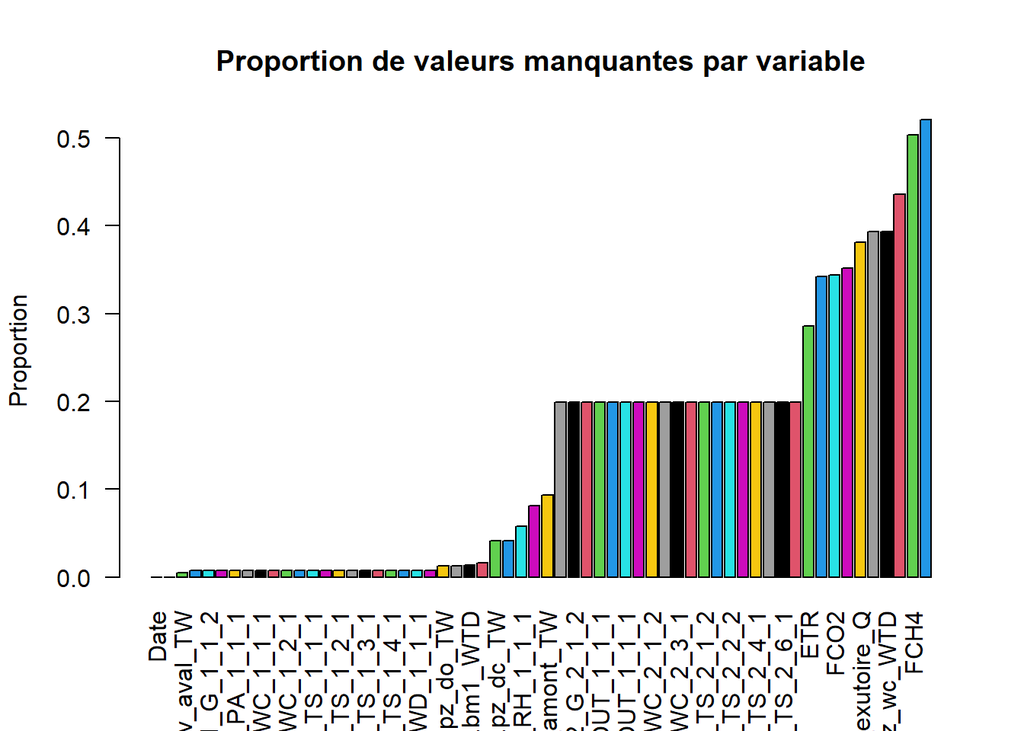

```r
barplot(na_prop, las = 2, col = c(1:60), main = "Proportion de valeurs manquantes par variable",
        ylab = "Proportion")
```

lgt.pz_wo_WTD est la variable qui a plus de manquante ~(52%) en suite FCH4

### Nombre de composante principales

```r
nbdim3 <- estim_ncpPCA(projet_st[,-1])
nbdim3
```

```
## $ncp
## [1] 5
##
## $criterion
##        0        1        2        3        4        5
## 823.6353 549.6189 500.1944 262.4909 137.0446 124.8573
```

### imputation par acp

```r
data_1 <- imputePCA(projet_st[,-1], ncp = nbdim3$ncp, method = "Regularized")
```

### Verifions la dimension et si ça contient des nas

```r
dim(data_1$completeObs)
```

```
## [1] 1807   59
```

```r
sum(is.na(data_1$completeObs))
```

```
## [1] 0
```

### Table contenant data sans NAs, et date

```r
p_df<-data.frame(cbind(projet_st[,1],data_1$completeObs))   # Version dataframe
p_st <- xts(p_df, order.by = dates) # Version time serie
```

### CO2 et CH4 sans les NAs

```r
co2<-as.numeric(p_df[,3])
ch4<-as.numeric(p_df[,4])
```

# Les valeurs abbérantes(Valeurs extremes dans notre cas)

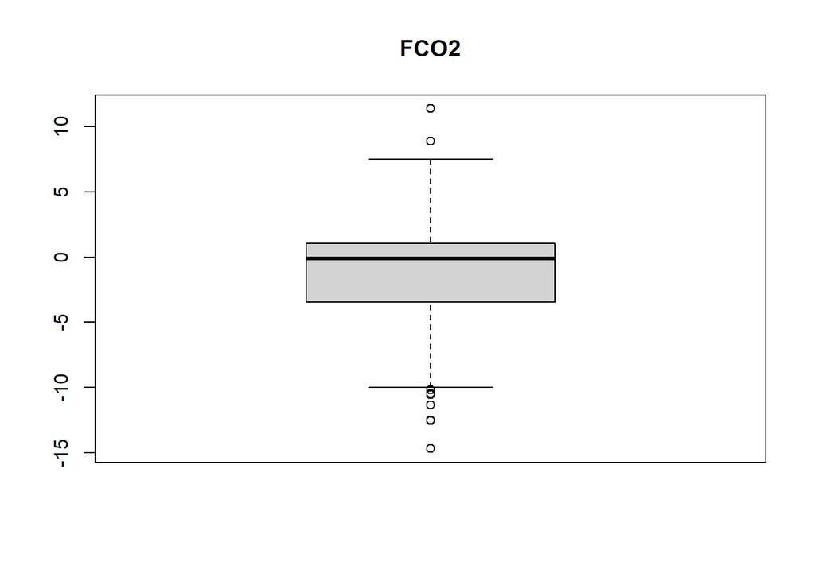

```r
boxplot(co2,main="FCO2")
```

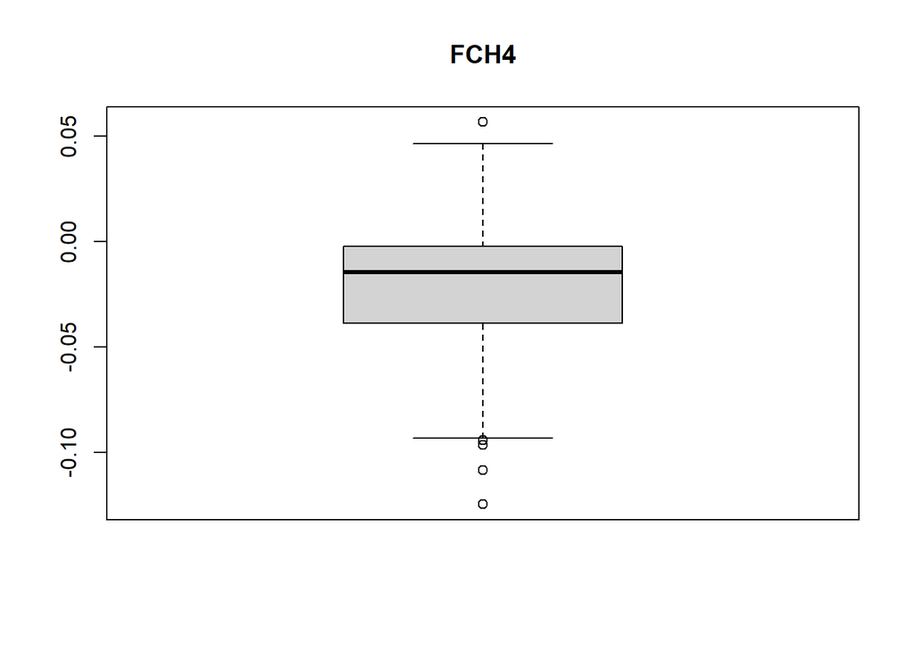

```r
boxplot(ch4,main="FCH4")
```

Les valeurs abérrantes dans FCO2

```r
ab_co2<-boxplot(co2,plot=F,main="FCO2")$out
length(ab_co2)
```

```
## [1] 10
```

```r
# Trouver les indices de ces valeurs dans le vecteur co2
ind_ab_co2 <- which(co2 %in% ab_co2)

# Toutes les lignes du tableau de ces valeurs
p_df[ind_ab_co2,1:4]
```

```
##              V1                 ETR              FCO2                 FCH4
## 171  2017-07-08  0.0435832266666667           8.91441 -0.00373037423969159
## 177  2017-07-14           0.2852895       -10.1793425  -0.0618294688694479
## 517  2018-06-19           0.0944942        -12.528625  -0.0468614736773946
## 528  2018-06-30       0.25189052375          -12.5177   -0.053447168362133
## 909  2019-07-16           0.3430058          -10.1947         -0.057823175
## 956  2019-09-01             0.31812          -10.4413           -0.0836777
## 1338 2020-09-17  0.0862262038242424           11.3887  -0.0110657606136364
## 1404 2020-11-22 0.00973989255541667           -14.695  -0.0113684365717949
## 1632 2021-07-08  0.0703817531942157        -10.530727  -0.0116186916594538
## 1634 2021-07-10  0.0863909785721063 -11.3576238461538  -0.0168476403398482
```

Les valeurs abérrantes dans FCH4

```r
ab_ch4<-boxplot(ch4,plot=F,main="FCH4")$out
length(ab_ch4)
```

```
## [1] 5
```

```r
# Trouver les indices de ces valeurs dans le vecteur co2
ind_ab_ch4 <- which(ch4 %in% ab_ch4)

# Toutes les lignes du tableau de ces valeurs
p_df[ind_ab_ch4,1:4]
```

```
##              V1           ETR               FCO2                FCH4
## 646  2018-10-26 -0.0023955715 -0.634964356807158           0.0567649
## 832  2019-04-30      0.119204           -1.12491           -0.124422
## 1189 2020-04-21    0.14254775           0.503428 -0.0961421833333333
## 1215 2020-05-17   0.216182625  -3.85665857142857 -0.0941995142857143
## 1221 2020-05-23      0.295495           -7.31002         -0.10826584
```

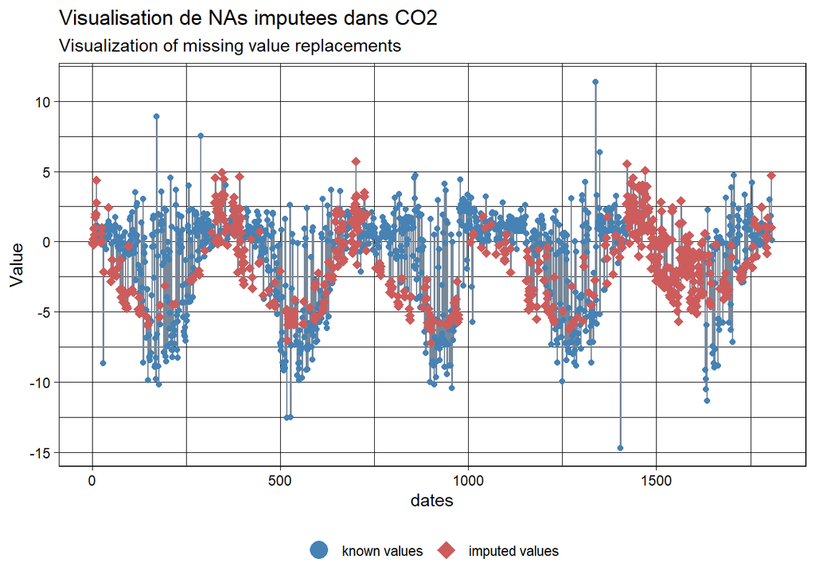

```r
ggplot_na_imputations(CO2,as.numeric(co2), xlab="dates", title ="Visualisation de NAs imputees dans CO2" )
```

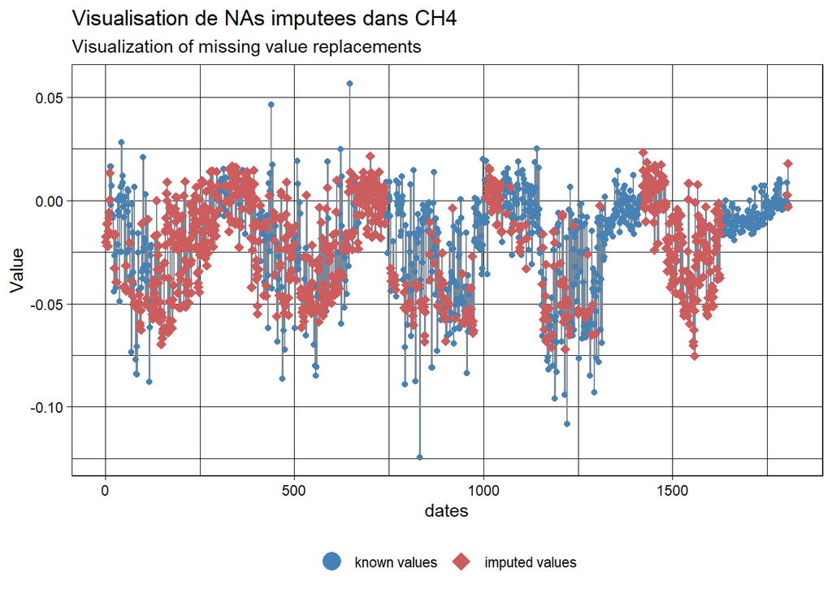

```r
ggplot_na_imputations(CH4,as.numeric(ch4), xlab="dates", title ="Visualisation de NAs imputees dans CH4" )
```

Enregistrement du fichier sans NA en Rdata

```r
save(p_df, file = "nona.RData")
```

## ACP

```r
df<-data.frame(p_df)
summary(df)
```

```
##       V1                ETR                FCO2               FCH4
##  Length:1807        Length:1807        Length:1807        Length:1807
##  Class :character   Class :character   Class :character   Class :character
##  Mode  :character   Mode  :character   Mode  :character   Mode  :character
##      Heat              LHeat            SoilHeatd2        lgt.bm1_G_1_1_2
##  Length:1807        Length:1807        Length:1807        Length:1807
##  Class :character   Class :character   Class :character   Class :character
##  Mode  :character   Mode  :character   Mode  :character   Mode  :character
##  lgt.bm1_P_1_1_1    lgt.bm1_PA_1_1_1   lgt.bm1_PPFD_IN_1_1_1 lgt.bm1_RH_1_1_1
##  Length:1807        Length:1807        Length:1807           Length:1807
##  Class :character   Class :character   Class :character      Class :character
##  Mode  :character   Mode  :character   Mode  :character      Mode  :character
##  lgt.bm1_SWC_1_1_1  lgt.bm1_SWC_1_1_2  lgt.bm1_SWC_1_2_1  lgt.bm1_SWC_1_3_1
##  Length:1807        Length:1807        Length:1807        Length:1807
##  Class :character   Class :character   Class :character   Class :character
##  Mode  :character   Mode  :character   Mode  :character   Mode  :character
##       TA            lgt.bm1_TS_1_1_1   lgt.bm1_TS_1_1_2   lgt.bm1_TS_1_2_1
##  Length:1807        Length:1807        Length:1807        Length:1807
##  Class :character   Class :character   Class :character   Class :character
##  Mode  :character   Mode  :character   Mode  :character   Mode  :character
##  lgt.bm1_TS_1_2_2   lgt.bm1_TS_1_3_1   lgt.bm1_TS_1_3_2   lgt.bm1_TS_1_4_1
##  Length:1807        Length:1807        Length:1807        Length:1807
##  Class :character   Class :character   Class :character   Class :character
##  Mode  :character   Mode  :character   Mode  :character   Mode  :character
##  lgt.bm1_TS_1_5_1   lgt.bm1_WD_1_1_1   lgt.bm1_WS_1_1_1   lgt.bm1_WTD
##  Length:1807        Length:1807        Length:1807        Length:1807
##  Class :character   Class :character   Class :character   Class :character
##  Mode  :character   Mode  :character   Mode  :character   Mode  :character
##  lgt.sm_exutoire_Q  lgt.sm_exutoire_TW lgt.pz_cbdv_amont_TW
##  Length:1807        Length:1807        Length:1807
##  Class :character   Class :character   Class :character
##  Mode  :character   Mode  :character   Mode  :character
##  lgt.pz_cbdv_amont_WTD lgt.pz_cbdv_aval_TW lgt.pz_cbdv_aval_WTD
##  Length:1807           Length:1807         Length:1807
##  Class :character      Class :character    Class :character
##  Mode  :character      Mode  :character    Mode  :character
##  lgt.pz_dc_TW       lgt.pz_dc_WTD      lgt.pz_do_TW       lgt.pz_do_WTD
##  Length:1807        Length:1807        Length:1807        Length:1807
##  Class :character   Class :character   Class :character   Class :character
##  Mode  :character   Mode  :character   Mode  :character   Mode  :character
```

[output cut: 9 more lines]

```
##  Length:1807         Length:1807          Length:1807        Length:1807
##  Class :character    Class :character     Class :character   Class :character
##  Mode  :character    Mode  :character     Mode  :character   Mode  :character
##  lgt.bm2_SWC_2_2_1  lgt.bm2_SWC_2_3_1  lgt.bm2_TS_2_1_1   lgt.bm2_TS_2_1_2
##  Length:1807        Length:1807        Length:1807        Length:1807
##  Class :character   Class :character   Class :character   Class :character
##  Mode  :character   Mode  :character   Mode  :character   Mode  :character
##  lgt.bm2_TS_2_2_1   lgt.bm2_TS_2_2_2   lgt.bm2_TS_2_3_1   lgt.bm2_TS_2_4_1
##  Length:1807        Length:1807        Length:1807        Length:1807
##  Class :character   Class :character   Class :character   Class :character
##  Mode  :character   Mode  :character   Mode  :character   Mode  :character
##  lgt.bm2_TS_2_5_1   lgt.bm2_TS_2_6_1   lgt.bm2_WTD
##  Length:1807        Length:1807        Length:1807
##  Class :character   Class :character   Class :character
##  Mode  :character   Mode  :character   Mode  :character
```

Rendons les variables numerics

```r
df[] <- lapply(df, function(x) as.numeric(x))
summary(df)
```

```
##        V1            ETR                 FCO2               FCH4
##  Min.   : NA    Min.   :-0.081941   Min.   :-14.6950   Min.   :-0.124422
##  1st Qu.: NA    1st Qu.: 0.005029   1st Qu.: -3.4310   1st Qu.:-0.038638
##  Median : NA    Median : 0.035192   Median : -0.1272   Median :-0.014251
##  Mean   :NaN    Mean   : 0.067131   Mean   : -1.2126   Mean   :-0.020132
##  3rd Qu.: NA    3rd Qu.: 0.104496   3rd Qu.:  1.0491   3rd Qu.:-0.002227
##  Max.   : NA    Max.   : 0.632089   Max.   : 11.3887   Max.   : 0.056765
##  NA's   :1807
##       Heat             LHeat           SoilHeatd2      lgt.bm1_G_1_1_2
##  Min.   :-83.635   Min.   :-61.470   Min.   :-19.250   Min.   :-32.452
##  1st Qu.:  4.638   1st Qu.:  8.058   1st Qu.: -4.430   1st Qu.: -5.069
##  Median : 44.346   Median : 35.248   Median : -1.284   Median : -1.923
##  Mean   : 56.827   Mean   : 55.049   Mean   : -1.369   Mean   : -1.716
##  3rd Qu.:106.906   3rd Qu.: 90.865   3rd Qu.:  1.717   3rd Qu.:  1.426
##  Max.   :335.518   Max.   :342.681   Max.   : 14.569   Max.   : 16.272
##
##  lgt.bm1_P_1_1_1   lgt.bm1_PA_1_1_1 lgt.bm1_PPFD_IN_1_1_1 lgt.bm1_RH_1_1_1
##  Min.   :-0.2599   Min.   : 961.5   Min.   :  0.0         Min.   :44.12
##  1st Qu.: 0.0000   1st Qu.: 994.9   1st Qu.:123.5         1st Qu.:76.26
##  Median : 0.2000   Median : 999.6   Median :265.3         Median :84.26
##  Mean   : 1.8520   Mean   : 999.1   Mean   :273.5         Mean   :82.91
##  3rd Qu.: 1.8000   3rd Qu.:1004.0   3rd Qu.:411.1         3rd Qu.:90.63
##  Max.   :43.8000   Max.   :1023.2   Max.   :635.5         Max.   :99.98
##
##  lgt.bm1_SWC_1_1_1 lgt.bm1_SWC_1_1_2 lgt.bm1_SWC_1_2_1 lgt.bm1_SWC_1_3_1
##  Min.   : 0.00     Min.   :29.92     Min.   : 0.00     Min.   :64.77
##  1st Qu.:34.18     1st Qu.:69.36     1st Qu.:70.04     1st Qu.:73.57
##  Median :40.84     Median :72.62     Median :76.53     Median :73.87
##  Mean   :37.43     Mean   :70.37     Mean   :69.59     Mean   :73.63
##  3rd Qu.:47.04     3rd Qu.:74.53     3rd Qu.:77.74     3rd Qu.:74.32
##  Max.   :64.09     Max.   :77.05     Max.   :79.43     Max.   :74.71
##
##        TA         lgt.bm1_TS_1_1_1 lgt.bm1_TS_1_1_2 lgt.bm1_TS_1_2_1
##  Min.   :-6.430   Min.   :-2.356   Min.   :-1.184   Min.   :-0.7548
##  1st Qu.: 6.443   1st Qu.: 5.949   1st Qu.: 6.370   1st Qu.: 6.1729
##  Median :10.728   Median : 9.867   Median :10.700   Median :10.0808
##  Mean   :10.744   Mean   :10.128   Mean   :10.917   Mean   :10.3748
##  3rd Qu.:15.359   3rd Qu.:14.720   3rd Qu.:15.894   3rd Qu.:14.9363
##  Max.   :26.062   Max.   :21.754   Max.   :22.762   Max.   :21.5054
##
```

[output cut: 73 more lines]

```
##  Min.   :-0.4046   Min.   : 1.250   Min.   : 0.233   Min.   : 2.521
##  1st Qu.: 5.9969   1st Qu.: 7.399   1st Qu.: 6.038   1st Qu.: 7.244
##  Median : 9.7373   Median :11.337   Median : 9.430   Median :10.301
##  Mean   :10.2244   Mean   :11.702   Mean   : 9.995   Mean   :10.751
##  3rd Qu.:14.8532   3rd Qu.:16.297   3rd Qu.:14.426   3rd Qu.:14.646
##  Max.   :20.8620   Max.   :22.662   Max.   :19.339   Max.   :18.658
##
##  lgt.bm2_TS_2_6_1  lgt.bm2_WTD
##  Min.   : 4.172   Min.   :-0.56381
##  1st Qu.: 7.871   1st Qu.:-0.09428
##  Median :10.394   Median :-0.03965
##  Mean   :10.710   Mean   :-0.07539
##  3rd Qu.:13.917   3rd Qu.:-0.03021
##  Max.   :16.892   Max.   : 0.28558
##
```

```r
library(ade4)

acp<-dudi.pca(df[,-c(1,3,4)],scal=T,scannf=F,nf=length(df[,-c(1,3,4)]))  ## ACP normee sans date,FCO2 et FCH4
class(acp)
```

```
## [1] "pca"  "dudi"
```

```r
names(acp)
```

```
##  [1] "tab"  "cw"   "lw"   "eig"  "rank" "nf"   "c1"   "li"   "co"   "l1"
## [11] "call" "cent" "norm"
```

```r
head(acp$li) ## Coordonnees des individus suivant  les axes factoriels
```

```
##      Axis1    Axis2     Axis3      Axis4      Axis5       Axis6        Axis7
## 1 9.783221 1.705149 -3.625396 -0.5150380 -0.4523877 -0.07840391  0.030758432
## 2 9.580653 1.825549 -3.178512  0.4500937 -0.4065486 -0.30173915  0.002255908
## 3 9.552377 2.507779 -2.908018  0.4809695 -0.4543654 -0.34819163 -0.254157288
## 4 9.468112 2.755260 -3.466829  0.5250097 -0.1306031 -0.46402974 -0.208497367
## 5 9.653005 2.936922 -1.911964  0.9350593 -1.0341262 -0.32221586 -0.523903505
## 6 9.779735 2.953519 -1.992313  0.4909171 -0.5795725 -0.43610604 -0.332410404
##        Axis8      Axis9      Axis10       Axis11       Axis12    Axis13
## 1  0.3409385  0.3482260  0.66200570  0.205393341 -0.217664483 0.1574720
## 2  0.1608654  0.1121742  0.32209648  0.125525196 -0.128650953 0.1672372
## 3 -0.3663581 -0.3556053 -0.18607637 -0.016695772 -0.005913295 0.3054089
## 4 -0.6305817 -0.4038449 -0.07344148 -0.037726382  0.087300558 0.3909635
## 5 -0.9562677 -0.4606860 -0.03382102 -0.043725907 -0.026423032 0.3252817
## 6 -0.7885136 -0.2498279 -0.03266653  0.008066254  0.181021417 0.2584813
##       Axis14      Axis15     Axis16     Axis17     Axis18     Axis19     Axis20
```

[output cut: 48 more lines]

## Pourcentage d’inertie sur les axes principaux avec la commande inertia.dudi

```r
inertie<-inertia.dudi(acp,col.inertia=F,row.inertia = T)  ## Ce sont des valeurs propres
head(inertie$tot.inertia)
```

```
##        inertia      cum   cum(%)
## Ax1 29.4640310 29.46403 51.69128
## Ax2  9.2788435 38.74287 67.96996
## Ax3  5.8773318 44.62021 78.28106
## Ax4  3.7735720 48.39378 84.90137
## Ax5  1.5742236 49.96800 87.66316
## Ax6  0.8908973 50.85890 89.22614
```

Representation des val.propres

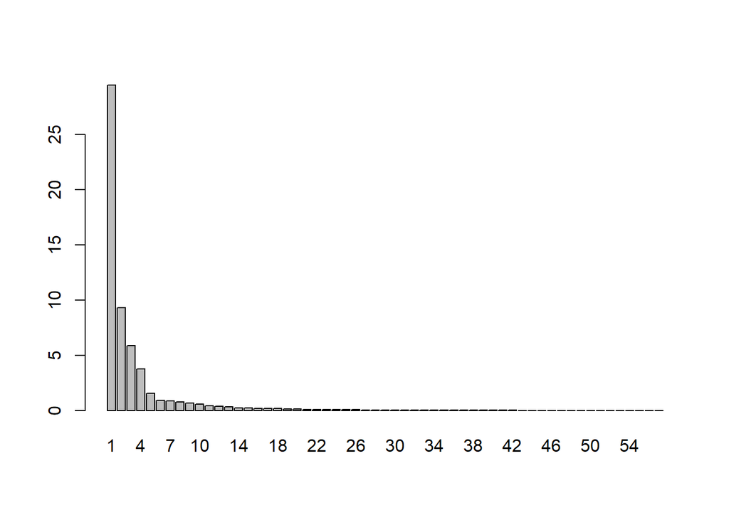

```r
barplot(acp$eig,names.arg=1:length(df[,-c(1,3,4)]))
```

## Cercles de correlation

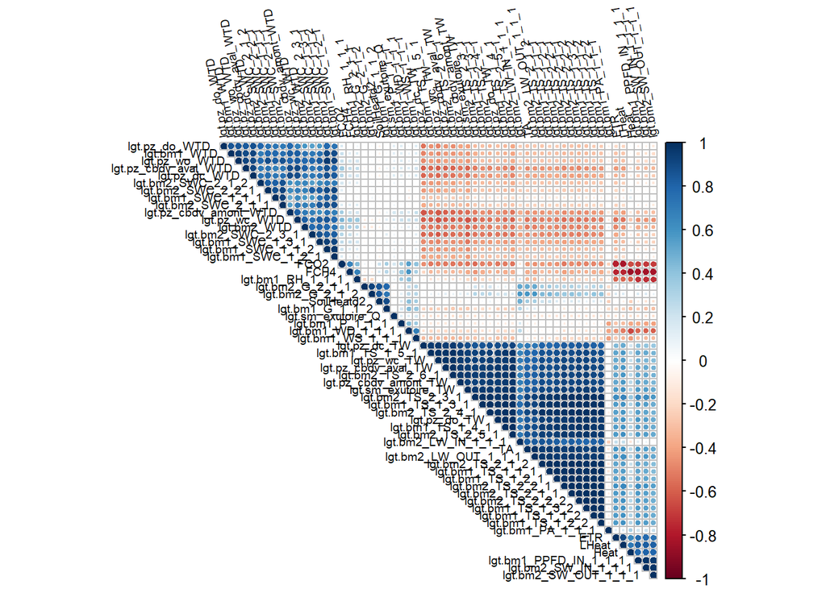

```r
# la correlation entre les variables

mcorr<-as.matrix(cor(df[,-1], use = "complete.obs"))  ## Matrice de correlation en ignorant les valeurs manquantes
corrplot(mcorr,type="upper",tl.cex=0.6, order="hclust",tl.col="black",tl.srt=100 )
```

```r
cc<-cor(df[,-c(1,3,4)],acp$li) # Correlation entre les axes factoriels et les variables
head(cc)
```

```
##                       Axis1        Axis2      Axis3      Axis4       Axis5
## ETR             -0.64236266 -0.112912081 -0.4117836  0.3614661  0.15077137
## Heat            -0.34037014 -0.253990282 -0.6988408  0.3413432  0.02474296
## LHeat           -0.67270809 -0.171605825 -0.4670978  0.3218326  0.07257006
## SoilHeatd2      -0.07630174 -0.034566924  0.6938487  0.6067321 -0.22819176
## lgt.bm1_G_1_1_2  0.14521651  0.006170156  0.6694720  0.5841370 -0.25600572
## lgt.bm1_P_1_1_1  0.14871528 -0.016363875  0.5173986 -0.1858478  0.36479587
##                       Axis6        Axis7       Axis8       Axis9      Axis10
## ETR              0.01444412  0.006339114  0.04234026 -0.15287456  0.02862201
## Heat            -0.02415850 -0.101113178 -0.03393854 -0.15490576  0.02800914
## LHeat            0.02320691  0.053326317  0.04120296 -0.17457914  0.02458614
## SoilHeatd2       0.07059406 -0.007600430  0.03836820 -0.05809509 -0.04012722
## lgt.bm1_G_1_1_2  0.06995551 -0.005794524 -0.03263952 -0.08036654 -0.03619315
## lgt.bm1_P_1_1_1 -0.11438338  0.003105254  0.24312018 -0.54214958  0.38141500
##                       Axis11       Axis12       Axis13      Axis14      Axis15
## ETR              0.421988347  0.037610159  0.025292625 -0.07896188  0.08843168
## Heat            -0.021805332 -0.102293593  0.164230203  0.17023251 -0.09004102
## LHeat            0.314550782 -0.009303979  0.064770168 -0.04185648  0.03936739
## SoilHeatd2       0.009032456 -0.135503743 -0.007257308 -0.05693418 -0.04324111
## lgt.bm1_G_1_1_2  0.014428953 -0.174816164 -0.095562975 -0.08027975 -0.04466101
## lgt.bm1_P_1_1_1 -0.159605482  0.017253180 -0.051812885 -0.02569822  0.02225759
##                       Axis16        Axis17       Axis18       Axis19
## ETR             -0.037299027  0.0009344143  0.033931441  0.020066001
## Heat             0.286298166  0.1241782052  0.044085339 -0.017052011
## LHeat           -0.009992977 -0.0564909870 -0.002018685 -0.012368741
## SoilHeatd2      -0.004672100  0.0258859397  0.041640961  0.036086932
## lgt.bm1_G_1_1_2  0.028805707  0.0142653425  0.143432603 -0.076834620
## lgt.bm1_P_1_1_1 -0.018735431  0.0125018549  0.018586443 -0.002889096
##                       Axis20       Axis21      Axis22       Axis23       Axis24
## ETR             -0.009188994  0.013219473 -0.03737986  0.110723228 -0.090260789
## Heat            -0.028698308  0.035125497  0.00271998  0.007308622 -0.015090274
## LHeat            0.001081633 -0.065851832  0.04127438 -0.145275821  0.104860821
## SoilHeatd2       0.098523808  0.078572280 -0.12129832 -0.110138043 -0.015529337
## lgt.bm1_G_1_1_2  0.094813524 -0.041737822  0.06661939  0.105828290  0.053308542
## lgt.bm1_P_1_1_1 -0.007846741  0.003582723  0.00537781 -0.001193613 -0.003802316
##                        Axis25       Axis26        Axis27        Axis28
## ETR              0.0765290235  0.014696949  0.0037499731 -0.0045562333
## Heat            -0.0074831102 -0.005179379  0.0161062551  0.0019224545
## LHeat           -0.0793531954 -0.001404493 -0.0125615583  0.0098508109
## SoilHeatd2       0.0659472192 -0.049231306  0.0309889041  0.0294963916
```

[output cut: 43 more lines]

```
## lgt.bm1_P_1_1_1 -1.270130e-04 -1.898216e-05 -3.291387e-05  7.095764e-05
##                        Axis53        Axis54        Axis55        Axis56
## ETR              2.001511e-05  3.114772e-05  7.125534e-06 -9.291019e-06
## Heat            -1.009348e-06 -2.956245e-05 -1.592757e-05  6.453344e-06
## LHeat           -1.325369e-05  8.616914e-06  3.005957e-05  8.734712e-07
## SoilHeatd2      -3.119229e-05  4.259876e-05  3.011772e-05 -1.858349e-05
## lgt.bm1_G_1_1_2 -1.667212e-04  1.300732e-04 -1.321598e-05  9.565298e-06
## lgt.bm1_P_1_1_1  1.403226e-06 -3.030451e-08 -4.701565e-06 -3.177416e-06
##                        Axis57
## ETR              1.781264e-06
## Heat            -1.478619e-06
## LHeat           -1.670549e-06
## SoilHeatd2       6.289103e-06
## lgt.bm1_G_1_1_2  6.664746e-06
## lgt.bm1_P_1_1_1 -1.000424e-06
```

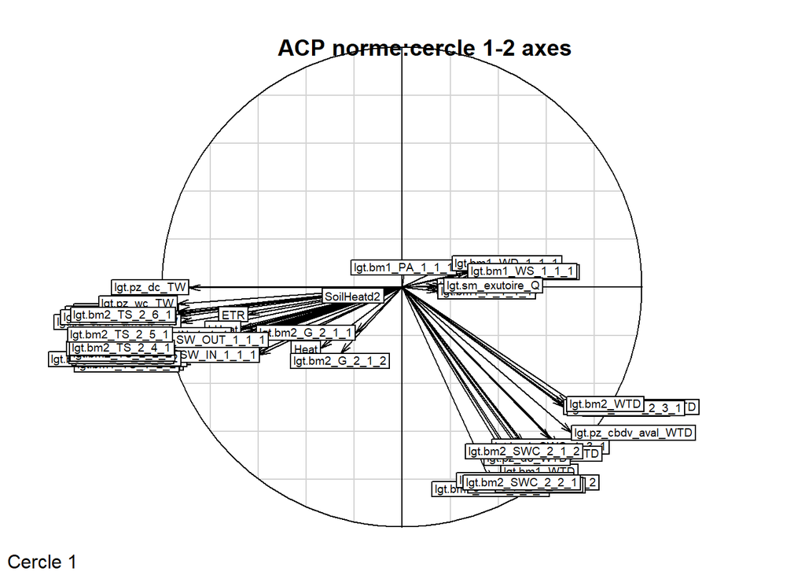

```r
s.corcircle(cc,xax=1,yax=2,clabel=0.6 , sub ="Cercle 1" )
title("ACP norme:cercle 1-2 axes")
```

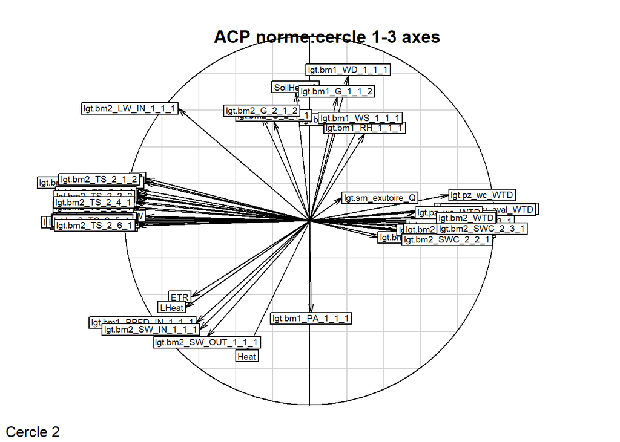

```r
s.corcircle(cc,xax=1,yax=3,clabel=0.6, sub ="Cercle 2")
title("ACP norme:cercle 1-3 axes")
```

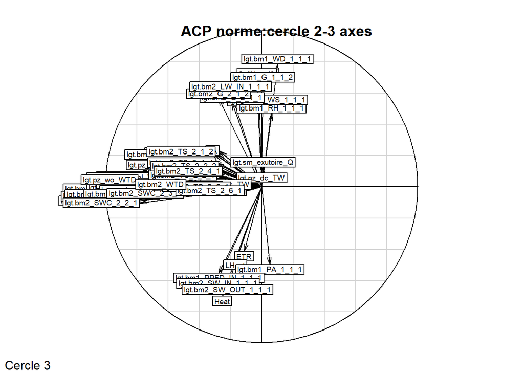

```r
s.corcircle(cc,xax=2,yax=3,clabel=0.6, sub ="Cercle 3")
title("ACP norme:cercle 2-3 axes")
```

Dans les 3 graphiques, on voit bien un regroupement des variables suivant les differents axes factoriels , surtout sur le cercle 1 et 3

### La projection des var suppllementaire (FCO2 et FCH4) sur les axes retenus

```r
var_sup <- scale(df[,c(3,4)])
cor_sup <- cor(var_sup,acp$li )  # corrélation avec les axes
head(cor_sup)
```

```
##          Axis1     Axis2     Axis3      Axis4      Axis5        Axis6
## FCO2 0.5620687 0.1400541 0.5213142 -0.1362507 -0.0122597 -0.009794688
## FCH4 0.4325035 0.1676419 0.6179814 -0.4155702 -0.1580959  0.017488381
##             Axis7       Axis8     Axis9       Axis10      Axis11      Axis12
## FCO2 0.0005845248 -0.04002609 0.1283227 -0.005655809 -0.29343220  0.03274781
## FCH4 0.0779920009  0.02635231 0.1037558 -0.006823847 -0.05641674 -0.00553847
##            Axis13      Axis14     Axis15      Axis16      Axis17      Axis18
## FCO2 -0.005542747  0.05051873 0.02157494 -0.03701585  0.04607764  0.01097298
## FCH4 -0.051643167 -0.09067185 0.04029335 -0.09352378 -0.08941073 -0.02168531
##             Axis19        Axis20      Axis21      Axis22      Axis23
## FCO2 -0.0062436707 -0.0009468872 -0.02277661 -0.02227809  0.07720559
## FCH4  0.0008760081  0.0169346265 -0.03543854  0.05168836 -0.03945927
##           Axis24      Axis25      Axis26      Axis27       Axis28      Axis29
## FCO2 -0.05061158  0.03163623 -0.03857466 -0.01388166 -0.025897743 -0.01469439
## FCH4  0.03026263 -0.02612292  0.01200264  0.03583926  0.008542158  0.01336086
##             Axis30      Axis31      Axis32       Axis33       Axis34
## FCO2 -0.0094495747 -0.01541347 -0.01659802 -0.006389245  0.018297781
## FCH4  0.0006963146 -0.01467051 -0.03281739  0.009395651 -0.007451886
##           Axis35     Axis36       Axis37      Axis38       Axis39     Axis40
## FCO2  0.01027067 0.02955052  0.042798198  0.02992031 -0.005027486 0.04969308
## FCH4 -0.01629499 0.01818527 -0.005335004 -0.01645150  0.012033599 0.02406007
##          Axis41      Axis42        Axis43      Axis44        Axis45      Axis46
## FCO2 0.00972744 -0.01505810  0.0105109490 0.008170875 -0.0084413780 -0.02320146
## FCH4 0.02547533 -0.01666253 -0.0000590353 0.041732285  0.0004138201  0.02796928
##           Axis47       Axis48      Axis49      Axis50       Axis51      Axis52
## FCO2 0.001631042  0.017132490 -0.02427833  0.01369374 -0.001773025 -0.01622575
## FCH4 0.041177588 -0.008654481  0.00155610 -0.03324411 -0.012043489  0.01795633
##            Axis53       Axis54      Axis55       Axis56      Axis57
## FCO2  0.003045498  0.005290039 0.022184365 -0.045473470  0.01013300
## FCH4 -0.007906548 -0.004583580 0.007934597  0.002399063 -0.01944611
```

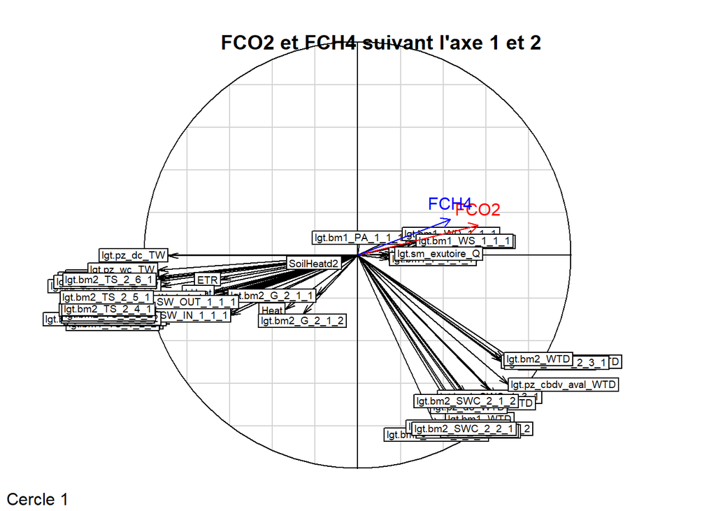

```r
# Ajout de FCO2 et FCH4 au cercle de correlation suivant l'axe 1 et 2

s.corcircle(cc,xax=1,yax=2,clabel=0.6 , sub ="Cercle 1" )  # Cercle des corrélations

arrows(0, 0, cor_sup[1,1], cor_sup[1,2], col = "red", length = 0.1)   #
text(cor_sup[1,1], cor_sup[1,2], labels = "FCO2", pos = 3, col = "red")

arrows(0, 0, cor_sup[2,1], cor_sup[2,2], col = "blue", length = 0.1)
text(cor_sup[2,1], cor_sup[2,2], labels = "FCH4", pos = 3, col = "blue")
title(" FCO2 et FCH4 suivant l'axe 1 et 2")
```

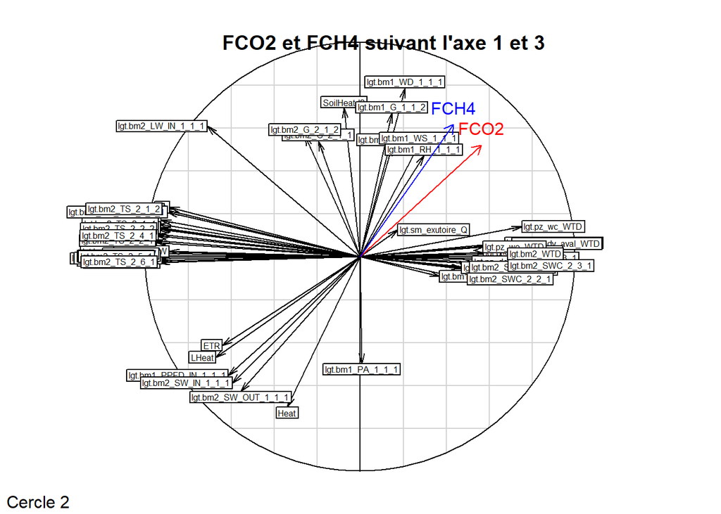

```r
# Ajouter les flèches des variables supplémentaires sur axes 1 et 3

s.corcircle(cc,xax=1,yax=3,clabel=0.5, sub ="Cercle 2")

arrows(0, 0, cor_sup[1,1], cor_sup[1,3], col = "red", length = 0.1)
text(cor_sup[1,1], cor_sup[1,3], labels = "FCO2", pos = 3, col = "red")

arrows(0, 0, cor_sup[2,1], cor_sup[2,3], col = "blue", length = 0.1)
text(cor_sup[2,1], cor_sup[2,3], labels = "FCH4", pos = 3, col = "blue")
title(" FCO2 et FCH4 suivant l'axe 1 et 3")
```

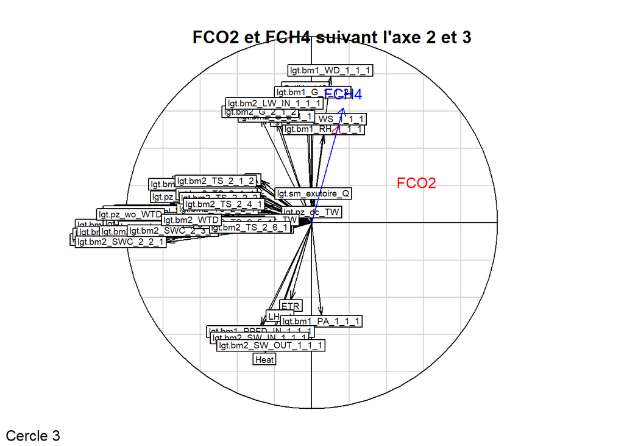

```r
# Ajouter les flèches des variables supplémentaires sur axes 2 et 3

s.corcircle(cc,xax=2,yax=3,clabel=0.6, sub ="Cercle 3")

arrows(0, 0, cor_sup[1,2], cor_sup[1,3], col = "red", length = 0.1)
text(cor_sup[1,1], cor_sup[1,2], labels = "FCO2", pos = 3, col = "red")

arrows(0, 0, cor_sup[2,2], cor_sup[2,3], col = "blue", length = 0.1)
text(cor_sup[2,2], cor_sup[2,3], labels = "FCH4", pos = 3, col = "blue")
title(" FCO2 et FCH4 suivant l'axe 2 et 3")
```

# Sélèctionons les variables correlées aux axes (contributions des variables à la création des composentes principales)

On pouvais se baser uniquement sur les figures pour commenter mais vu qu’on a 3 composante, c’est mieux d’en ajouter les valeurs pour être plus concrète - A l’axe 1

```r
seuil=0.5
cor1<-cc[abs(cc[,1])>=seuil,,drop=F]
nrow(cor1)
```

```
## [1] 43
```

```r
rownames(cor1)
```

```
##  [1] "ETR"                   "LHeat"                 "lgt.bm1_PPFD_IN_1_1_1"
##  [4] "lgt.bm1_SWC_1_1_2"     "lgt.bm1_SWC_1_2_1"     "lgt.bm1_SWC_1_3_1"
##  [7] "TA"                    "lgt.bm1_TS_1_1_1"      "lgt.bm1_TS_1_1_2"
## [10] "lgt.bm1_TS_1_2_1"      "lgt.bm1_TS_1_2_2"      "lgt.bm1_TS_1_3_1"
## [13] "lgt.bm1_TS_1_3_2"      "lgt.bm1_TS_1_4_1"      "lgt.bm1_TS_1_5_1"
## [16] "lgt.bm1_WTD"           "lgt.sm_exutoire_TW"    "lgt.pz_cbdv_amont_TW"
## [19] "lgt.pz_cbdv_amont_WTD" "lgt.pz_cbdv_aval_TW"   "lgt.pz_cbdv_aval_WTD"
## [22] "lgt.pz_dc_TW"          "lgt.pz_dc_WTD"         "lgt.pz_do_TW"
## [25] "lgt.pz_do_WTD"         "lgt.pz_wc_TW"          "lgt.pz_wc_WTD"
## [28] "lgt.pz_wo_WTD"         "lgt.bm2_LW_IN_1_1_1"   "lgt.bm2_LW_OUT_1_1_1"
## [31] "lgt.bm2_SW_IN_1_1_1"   "lgt.bm2_SW_OUT_1_1_1"  "lgt.bm2_SWC_2_1_2"
## [34] "lgt.bm2_SWC_2_3_1"     "lgt.bm2_TS_2_1_1"      "lgt.bm2_TS_2_1_2"
## [37] "lgt.bm2_TS_2_2_1"      "lgt.bm2_TS_2_2_2"      "lgt.bm2_TS_2_3_1"
## [40] "lgt.bm2_TS_2_4_1"      "lgt.bm2_TS_2_5_1"      "lgt.bm2_TS_2_6_1"
## [43] "lgt.bm2_WTD"
```

- A l’axe 1 negativement

```r
cor1N<-cc[cc[,1]<=(-seuil),,drop=F]
nrow(cor1N)
```

```
## [1] 30
```

```r
rownames(cor1N)
```

```
##  [1] "ETR"                   "LHeat"                 "lgt.bm1_PPFD_IN_1_1_1"
##  [4] "TA"                    "lgt.bm1_TS_1_1_1"      "lgt.bm1_TS_1_1_2"
##  [7] "lgt.bm1_TS_1_2_1"      "lgt.bm1_TS_1_2_2"      "lgt.bm1_TS_1_3_1"
## [10] "lgt.bm1_TS_1_3_2"      "lgt.bm1_TS_1_4_1"      "lgt.bm1_TS_1_5_1"
## [13] "lgt.sm_exutoire_TW"    "lgt.pz_cbdv_amont_TW"  "lgt.pz_cbdv_aval_TW"
## [16] "lgt.pz_dc_TW"          "lgt.pz_do_TW"          "lgt.pz_wc_TW"
## [19] "lgt.bm2_LW_IN_1_1_1"   "lgt.bm2_LW_OUT_1_1_1"  "lgt.bm2_SW_IN_1_1_1"
## [22] "lgt.bm2_SW_OUT_1_1_1"  "lgt.bm2_TS_2_1_1"      "lgt.bm2_TS_2_1_2"
## [25] "lgt.bm2_TS_2_2_1"      "lgt.bm2_TS_2_2_2"      "lgt.bm2_TS_2_3_1"
## [28] "lgt.bm2_TS_2_4_1"      "lgt.bm2_TS_2_5_1"      "lgt.bm2_TS_2_6_1"
```

- A l’axe 1 positivement

```r
cor1p<-cc[cc[,1]>=(seuil),,drop=F]
nrow(cor1p)
```

```
## [1] 13
```

```r
rownames(cor1p)
```

```
##  [1] "lgt.bm1_SWC_1_1_2"     "lgt.bm1_SWC_1_2_1"     "lgt.bm1_SWC_1_3_1"
##  [4] "lgt.bm1_WTD"           "lgt.pz_cbdv_amont_WTD" "lgt.pz_cbdv_aval_WTD"
##  [7] "lgt.pz_dc_WTD"         "lgt.pz_do_WTD"         "lgt.pz_wc_WTD"
## [10] "lgt.pz_wo_WTD"         "lgt.bm2_SWC_2_1_2"     "lgt.bm2_SWC_2_3_1"
## [13] "lgt.bm2_WTD"
```

- A l’axe 2

```r
cor2<-cc[abs(cc[,2])>=seuil,,drop=F]
nrow(cor2)
```

```
## [1] 14
```

```r
rownames(cor2)
```

```
##  [1] "lgt.bm1_SWC_1_1_1"    "lgt.bm1_SWC_1_1_2"    "lgt.bm1_SWC_1_2_1"
##  [4] "lgt.bm1_SWC_1_3_1"    "lgt.bm1_WTD"          "lgt.pz_cbdv_aval_WTD"
##  [7] "lgt.pz_dc_WTD"        "lgt.pz_do_WTD"        "lgt.pz_wc_WTD"
## [10] "lgt.pz_wo_WTD"        "lgt.bm2_SWC_2_1_1"    "lgt.bm2_SWC_2_1_2"
## [13] "lgt.bm2_SWC_2_2_1"    "lgt.bm2_SWC_2_3_1"
```

- A l’axe 2 negativement

```r
cor2N<-cc[cc[,2]<=(-seuil),,drop=F]
nrow(cor2N)
```

```
## [1] 14
```

```r
rownames(cor2N)
```

```
##  [1] "lgt.bm1_SWC_1_1_1"    "lgt.bm1_SWC_1_1_2"    "lgt.bm1_SWC_1_2_1"
##  [4] "lgt.bm1_SWC_1_3_1"    "lgt.bm1_WTD"          "lgt.pz_cbdv_aval_WTD"
##  [7] "lgt.pz_dc_WTD"        "lgt.pz_do_WTD"        "lgt.pz_wc_WTD"
## [10] "lgt.pz_wo_WTD"        "lgt.bm2_SWC_2_1_1"    "lgt.bm2_SWC_2_1_2"
## [13] "lgt.bm2_SWC_2_2_1"    "lgt.bm2_SWC_2_3_1"
```

- A l’axe 2 positivement

```r
cor2p<-cc[cc[,2]>=(seuil),,drop=F]
nrow(cor2p)
```

```
## [1] 0
```

```r
rownames(cor2p)
```

A l’axe 3

```r
cor3<-cc[abs(cc[,3])>=seuil,,drop=F]
nrow(cor3)
```

```
## [1] 12
```

```r
rownames(cor3)
```

```
##  [1] "Heat"                  "SoilHeatd2"            "lgt.bm1_G_1_1_2"
##  [4] "lgt.bm1_P_1_1_1"       "lgt.bm1_PPFD_IN_1_1_1" "lgt.bm1_WD_1_1_1"
##  [7] "lgt.bm1_WS_1_1_1"      "lgt.bm2_G_2_1_1"       "lgt.bm2_G_2_1_2"
## [10] "lgt.bm2_LW_IN_1_1_1"   "lgt.bm2_SW_IN_1_1_1"   "lgt.bm2_SW_OUT_1_1_1"
```

- A l’axe 3 negativement

```r
cor3N<-cc[cc[,3]<=(-seuil),,drop=F]
nrow(cor3N)
```

```
## [1] 4
```

```r
rownames(cor3N)
```

```
## [1] "Heat"                  "lgt.bm1_PPFD_IN_1_1_1" "lgt.bm2_SW_IN_1_1_1"
## [4] "lgt.bm2_SW_OUT_1_1_1"
```

- A l’axe 3 positivement

```r
cor3p<-cc[cc[,3]>=(seuil),,drop=F]
nrow(cor3p)
```

```
## [1] 8
```

```r
rownames(cor3p)
```

```
## [1] "SoilHeatd2"          "lgt.bm1_G_1_1_2"     "lgt.bm1_P_1_1_1"
## [4] "lgt.bm1_WD_1_1_1"    "lgt.bm1_WS_1_1_1"    "lgt.bm2_G_2_1_1"
## [7] "lgt.bm2_G_2_1_2"     "lgt.bm2_LW_IN_1_1_1"
```

### Correlations des FCO2 et CH4 axes suivant les 3 axes

```r
cor_sup[,1:4]
```

```
##          Axis1     Axis2     Axis3      Axis4
## FCO2 0.5620687 0.1400541 0.5213142 -0.1362507
## FCH4 0.4325035 0.1676419 0.6179814 -0.4155702
```

### Commentaire

D’après les cercles de correlation et les parties qui précèdent, on a :

- Moyennement 43 variables qui sont correlées avec l’axe1 et repartient comme suit : 30 négativement et 13 positivement . Et FCO2 aussi est correlée avec l’axe1 donc il y’a dépendance entre FCO2 et ces 43 variables
- Moyennement 14 variables qui sont correlées avec l’axe2 et toute négativement . Mais FCO2 et FCH4 sont très faiblement correlées à l’axe2 donc pas de dépendance avec ces 14 variables
- Moyennement 12 variables qui sont correlées avec l’axe3 et repartient comme suit : 4 négativement et 8 positivement . Et FCO2 et FCH4 sont aussi correlées avec l’axe3 donc il y’a dépendance entre FCO2,CH4 et ces 12 variables

-43 variables contribuent à l’axe 1 et 30 sont négativement correlées à 13(ie une date qui a les 30 variables avec une grande valeur aura une faible valeur pour les 13 autres variables . VIS-VERSA )

- Pour l’axe 2, 14 variables contribuent à sa formation et sont toutes correlées positivement entre elles
- Pour l’axe 3, 12 contribuent a sa formation et 4 variables sont correlées négativement à 8 .